# Reproducibility analysis: Huang et al. (2019)

A reproducibility analysis of discrete-event simulation in healthcare

Analysis

Reproducibility

R

Author

Tom Slater

Published

March 14, 2025

This article documents a reproducibility analysis of a 2019 paper by Huang et al. in health simulation [1]. I will make extensive reference to the paper throughout the report and so to give full recognition to the authors, the reference is provided below.

**Original Paper**

Huang, S., et al. Optimizing Resources for Endovascular Clot Retrieval for Acute Ischemic Stroke, a Discrete Event Simulation. Front Neurol, 2019. 10: p. 653. https://doi.org/10.3389/fneur.2019.00653.

The code associated with the paper can be found on GitHub [2] and is freely available under the GPL-3.0 licence.

**Source Code**

Huang, S., et al. desECR. 2019 [Accessed: 13/03/2025]; Available from: https://github.com/shiweih/desECR.git.

**Time to read:** 8 minutes

## INTRODUCTION

Reproducible research is critical. Publishing work that can be understood, replicated and developed by others is key to accelerating growth in any field. Yet, research as a whole is not reproducible [3], perhaps alarmingly so, and in the interest of this article, modelling and simulation is certainly no exception [4,5].

Reproducibility is even more vital when modelling in a healthcare setting, given the potential ethical implications of the work. When taking the Hippocratic Oath, doctors promise to share their knowledge to advance healthcare, but there is no such mandate for health data scientists. Nonetheless, health data scientists ought to hold an individual responsibility to facilitate the sharing of their work. This can and will only ever be achieved if reproducibility best practices are adhered to.

In an attempt to encourage reproducible research in health simulation, I am documenting my findings from a reproducibility analysis on a discrete-event simulation paper. I will introduce the model and discuss my attempts to reproduce the key results later in the article.

## DISCRETE-EVENT SIMULATION

Before proceeding, I will briefly mention what discrete-event simulation is (henceforth referred to as DES).

DES is a type of simulation model, typically used in operational research. It models arrivals, exits and internal movements within a system as a network of entities, resources and queues [6]. Individual entities may enter the system, leave the system, occupy a resource or queue for a resource at any given time.

A fundamental property of DES is that changes to a system can only occur when events are triggered [7]. Thus, time progression is directly dictated by discrete events (hence, *discrete-event* simulation). Several discrete events may occur at once and so a key area of interest is the order in which DES deals with these [6].

DES is frequently applied to investigate patient flows within a range of healthcare settings. The paper of focus, *‘Optimizing Resources for Endovascular Clot Retrieval for Acute Ischemic Stroke, a Discrete Event Simulation’,* is one such example.

## THE MODEL

In the paper, DES is used to model endovascular clot retrieval (ECR) treatment allocation for acute ischaemic stroke (AIS) patients. AIS patients are in direct competition for resources with elective non-stroke interventional neuroradiology (elective INR), emergency interventional radiology (emergency IR) and elective interventional radiology (elective IR) patients. The system diagram below shows the possible patient pathways, including arrival, queuing, resource occupancy and system exits. For more detailed model information, please refer to the original paper [1].

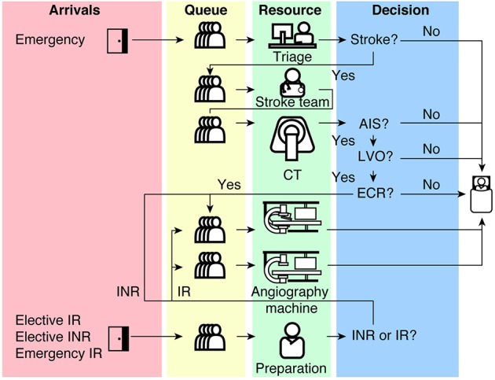

Figure 1 taken from Huang et al., 2019 [1]

Huang et al. were interested in how patient waiting times and resource usage varied under different scenarios:

1. **Baseline:** standard procedure under specified parameters.
2. **Exclusive-use:** elective IR patients restricted to use of only the IR angiography machine.
3. **Double angio INRs:** an extra INR angiography machine in place of an IR one.

The impact of adding an extra one and two hours to daytime shifts was also trialled under each of these scenarios.

The key results of the paper are figures 2-5, as well as a supplementary figure, which was submitted with the article. The success of my reproduction attempts were directly assessed against these five plots.

## CODE

The R package `simmer` is used for running the simulations. The package is designed for DES model implementation and documentation can be found at https://cran.r-project.org/web/packages/simmer/index.html [8].

In order for a reproducibility analysis to be performed in the first place, open code must be provided and this has been done by the authors via GitHub (found at https://github.com/shiweih/desECR [2]). Huang et al. ought to be commended for doing this, as this in itself drastically increases the reproducibility of their work. However, in general this is not enough; code that is not readable or fails to run is not of much use to anyone. Fortunately, I did not find this to be the case here. Though additional comments may have been useful, reasonable knowledge of `simmer` and DES theory is sufficient to grasp the model. I was also pleased to discover that the function used to run the simulations worked fine and was easily adaptable. The only minor criticism I had was that, to me at least, the purpose of the plotting function was unclear, as none of the plots were relevant to those in the paper. I hence removed this function from my own code and devised some plotting functions from scratch.

## RESULTS

In line with the original study, I repeated simulations for each of the scenarios thirty times. A reproducibility seed of `11032025` was used, as a nod to the date simulations were run. The amount of time spent on figure reproductions was not pre-specified. I simply kept on going until I had reached a point that reflected a ‘best’ attempt. Whilst it may have been better practice to give myself a timed cut-off, or at least to document some timings, this analysis served as an introduction to DES for me and so lines between learning general DES coding and specific model comprehension and modification often became blurred. Experienced researchers ought to be more rigorous with their time spent.

**FIGURE 2**

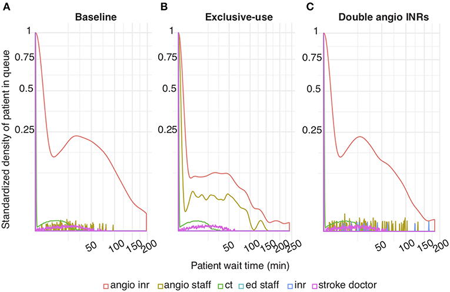

Figure 2 taken from Huang et al., 2019 [1]

My attempt to recreate figure 2 from the paper was for the most part unsuccessful. The closest plot I produced did not sufficiently match the original, despite there being some similarities. In short, the density shapes are inconsistent in most cases and specific values are out.

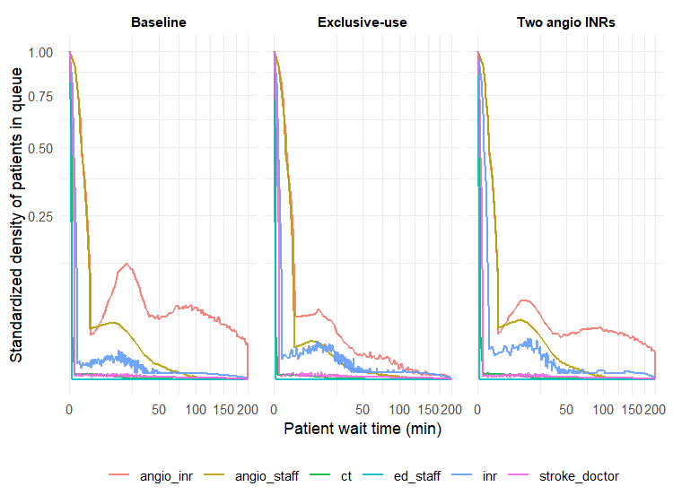

Reproduction of figure 2 from Huang et al., 2019 [1]

**FIGURE 3**

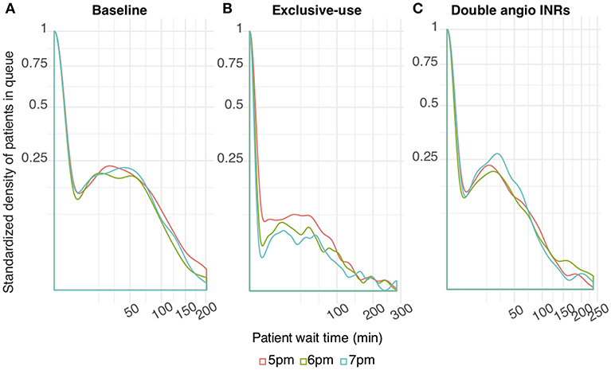

Figure 3 taken from Huang et al., 2019 [1]

Reproduction of figure 3 was also not achieved. Similar to figure 2, the densities are not consistent with the original plot. On top of this, the results I obtained for the baseline and double angio INR scenarios suggest a slight reduction in the waiting times when additional hours are added to the shift. This is a direct contradiction to a conclusion from the paper: only the exclusive-use scenario was found to see a significant drop in the wait times with one and two hours of extra work.

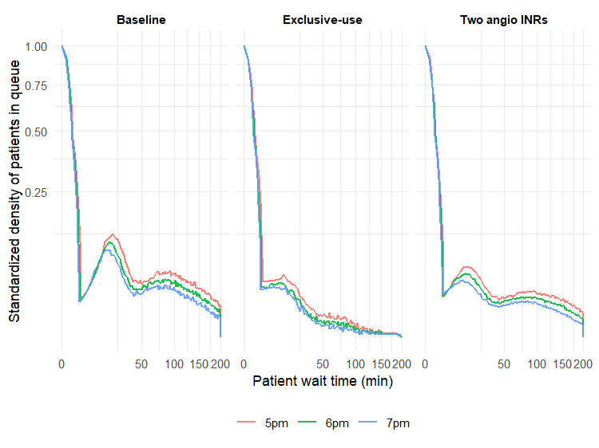

Reproduction of figure 3 from Huang et al., 2019 [1]

**FIGURE 4**

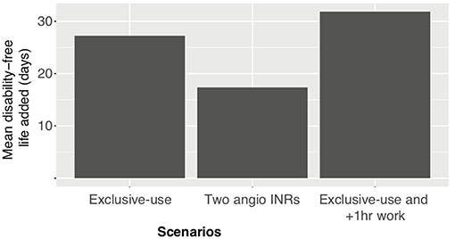

Figure 4 taken from Huang et al., 2019 [1]

I was close to being able to reproduce figure 4. My resulting plot had a similar shape to the original figure and the general conclusions associated with it were reached. However, the exact mean values for disability-free life are not quite consistent with those Huang et al. obtained and so it is difficult to claim true reproducibility with this being the case.

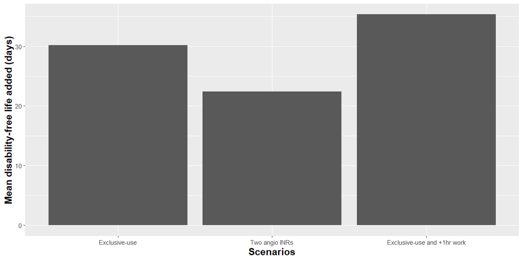

Reproduction of figure 4 from Huang et al., 2019 [1]

**FIGURE 5**

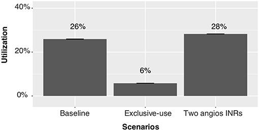

Figure 5 taken from Huang et al., 2019 [1]

Again, reproducing figure 5 was very nearly achieved, but not quite. I managed to obtain similar angio INR utilisation percentages when compared to the original. The value for the two angio INR scenario was in fact an exact match, but the other two were slightly out and so were not reproduced.

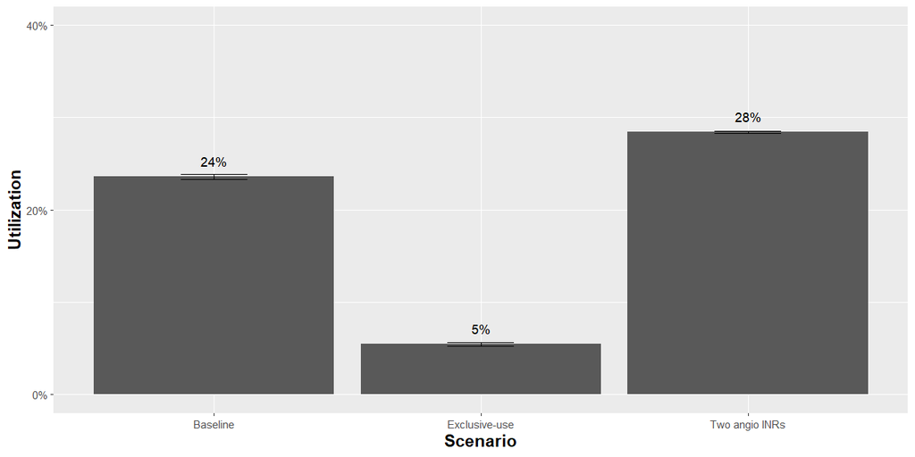

Reproduction of figure 5 from Huang et al., 2019 [1]

**SUPPLEMENTARY FIGURE**

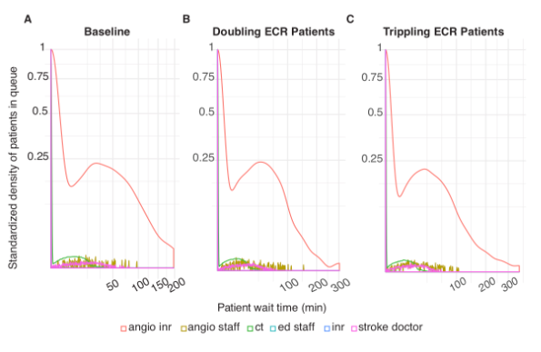

The supplementary figure associated with Huang et al., 2019 [1]

The methods required to reproduce the supplementary figure were largely similar to those used for figures 2 and 3 and so unsurprisingly reproduction was unsuccessful. I did, however, manage to get somewhat consistent patterns to the paper - i.e. double and triple the number of patients follow a similar trend to the baseline number of patients - but the densities were not a match.

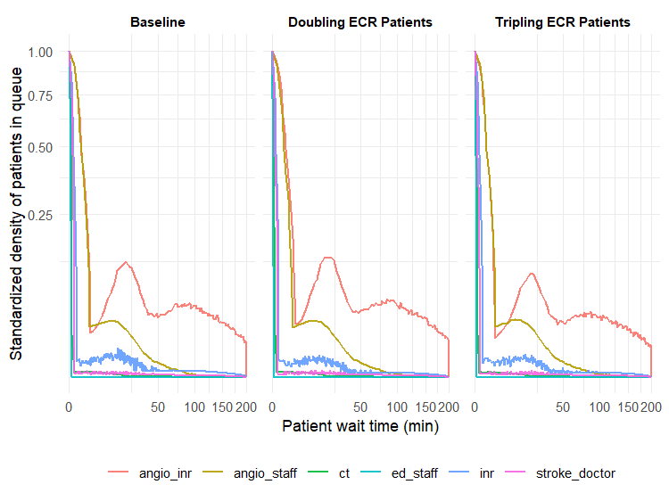

Reproduction of the supplementary figure from Huang et al., 2019 [1]

## CHALLENGES

**SEED FOR REPRODUCIBILITY**

The model included elements of stochasticity, yet these were not controlled for through the use of a random seed. Without a reproducible seed, the output obtained by Huang et al. and my own output were subject to randomness and so results were unlikely to align. This made it difficult to decipher whether discrepancies in the results were just due to randomness or if it was something else.

**WAITING TIME PROBABILITIES**

Producing figures 2 and 3, as well as the supplementary figure, required the standardisation of mean waiting times. An explanation of how this was carried out was not included in the paper, mandating the inclusion of my own guess work. In all likelihood, the method I used was not the same as the one in the paper but I settled on it as a best attempt.

The approach I used can be summarised as follows:

1. Assign all non-zero wait times into a set number of bins.
2. Reassign all values as the midpoint of the bin they are collected in.
3. Divide the frequency of values in each bin by the overall number of patients who did not wait at all, so that a ratio is obtained.
4. Transform the ratios using the sigmoid function: $f(x) = \frac{1}{1+e^{-r}}$, where $r$ is the ratio.

**MEAN DISABILITY-FREE LIFE DAYS ADDED**

It was clear from the paper that the output of figure 4 was just a function of the waiting times for ECR patients. What I was unsure about was which resources the waiting time applied to. Initially, I took the average of all resources used by an ECR patient, but this looked very wrong. I eventually settled on waiting times for just the angio INR resource.

## FINAL COMMENTS

It should be said that the intention of this article is not to criticise the work of Huang et al. It is merely meant to advocate for the need for reproducibility and to document my attempts to reproduce this particular piece of work. Huang et al. should be commended for their strong research: they successfully constructed a complex DES model and achieved some substantial and impactful results. Nonetheless, it is my conclusion that their work is not able to be reproduced. Importantly, this is my conclusion. The results obtained are exclusively my attempts and it may be that others can in fact reproduce the figures successfully. But to the best of my ability I believe it cannot be done. So, despite a thorough piece of research, the paper cannot be verified. I would, however, argue that Huang et al. have provided us with something that can be easily manipulated and developed for use in a similar healthcare application. Their code was very readable and ran well, it was just the specific plots that proved problematic.

Advocating for computationally reproducibility, I ought to make sufficient attempts to ensure the results in this article are themselves reproducible. In light of this, I have upload my code to GitHub https://github.com/tbslater/huang-reproducibility-analysis.git. Please do not hesitate to get in touch if you have any questions or feedback from this piece of analysis.

## REFERENCES

1. Huang, S., et al. Optimizing Resources for Endovascular Clot Retrieval for Acute Ischemic Stroke, a Discrete Event Simulation. Front Neurol, 2019. 10: p. 653.
2. Huang, S., et al. desECR. 2019 [Accessed: 13/03/2025]; Available from: https://github.com/shiweih/desECR.git.
3. Hudson, R. Should We Strive to Make Science Bias-Free? A Philosophical Assessment of the Reproducibility Crisis. Journal for General Philosophy of Science, 2021. 52(3): p. 389-405.
4. Monks, T., et al. The simulation reproducibility crisis. Can reporting guidelines help? 2017. Operational Research Society.
5. Taylor, S.J.E., et al. CRISIS, WHAT CRISIS – DOES REPRODUCIBILITY IN MODELING & SIMULATION REALLY MATTER? in 2018 Winter Simulation Conference (WSC). 2018.
6. Schriber, T.J. and D.T. Brunner. Inside discrete-event simulation software: How it works and why it matters. in 2007 Winter Simulation Conference. 2007.
7. Zhang, P., Chapter 19 - Industrial control system simulation routines, in Advanced Industrial Control Technology, P. Zhang, Editor. 2010, William Andrew Publishing: Oxford. p. 781-810.
8. Ucar, I., B. Smeets, and A. Azcorra, simmer: Discrete-Event Simulation for R. Journal of Statistical Software, 2019. 90(2): p. 1-30.